# Infodengue

##### info.dengue.mat.br

Esse Jupyter notebook, descreve como acessar e fazer visualizações a partir da tabela de dados do Infodengue usando a linguagem Python. Mais informações sobre os dados e como citar o Infodengue, consulte aqui.

Para executar esse notebook, as seguintes bibliotecas são necessárias:

```python
import pandas as pd
import numpy as np
import matplotlib.pyplot as plt
```

# Consulta de dados

As tabelas geradas pelo Infodengue contem dados agregados por semana provenientes de diferentes fontes. Elas podem ser consultadas via formulário, ou diretamente do Python (como mostraremos mais adiante), por meio de uma consulta à API. Essa funcionalidade está disponível por meio da URL: https://info.dengue.mat.br/api/alertcity?PARAMETROS_DA_CONSULTA Onde PARAMETROS_DA_CONSULTA deve conter os parâmetros:

geocode: código IBGE da cidade

disease: tipo de doença a ser consultado (str:dengue|chikungunya|zika)

format: formato de saída dos dados (str:json|csv)

ew_start: semana epidemiológica de início da consulta (int:1-53)

ew_end: semana epidemiológica de término da consulta (int:1-53)

ey_start: ano de início da consulta (int:0-9999)

ey_end: ano de término da consulta (int:0-9999)

Todos os parâmetros acima mencionados são obrigatórios para a consulta. Abaixo, segue exemplo de requisição de registros de dengue entre a semana 1 e 50 do ano de 2017, no Rio de Janeiro (geocodigo = 3304557) em formato CSV: https://info.dengue.mat.br/api/alertcity?geocode=3304557&disease=dengue&format=csv&ew_start=1&ew_end=50&ey_start=2017&ey_end=2017

### Como fazer no Python?

1. Defina os parâmetros e verifique se a consulta está correta:

```python
url = "https://info.dengue.mat.br/api/alertcity?"
geocode = 3304557
disease = "dengue"
format = "csv"
ew_start = 1
ew_end = 52
ey_start = 2017
ey_end = 2018

# não mexer
cons1 = print(url,"geocode=",geocode,"&disease=",disease,"&format=",format,"&ew_start=",ew_start,"&ew_end=",ew_end,"&ey_start=",ey_start,"&ey_end=",ey_end, sep = '')
cons1
```

```
https://info.dengue.mat.br/api/alertcity?geocode=3304557&disease=dengue&format=csv&ew_start=1&ew_end=52&ey_start=2017&ey_end=2018
```

1. Executar a consulta:

```python
dados = pd.read_csv('https://info.dengue.mat.br/api/alertcity?geocode=3304557&disease=dengue&format=csv&ew_start=1&ew_end=50&ey_start=2017&ey_end=2017')
dados
```

|  | data_iniSE | SE | casos_est | casos_est_min | casos_est_max | casos | p_rt1 | p_inc100k | Localidade_id | nivel | ... | versao_modelo | tweet | Rt | pop | tempmin | umidmax | receptivo | transmissao | nivel_inc | notif_accum_year |
| --- | --- | --- | --- | --- | --- | --- | --- | --- | --- | --- | --- | --- | --- | --- | --- | --- | --- | --- | --- | --- | --- |
| 0 | 2017-01-01 | 201701 | 164.0 | 164 | 164 | 164 | 9.784580e-01 | 2.523530 | 0 | 2 | ... | 2020-12-07 | 68.0 | 1.0 | 6498837.0 | 26.0 | NaN | 1 | 0 | 0 | 4668 |
| 1 | 2017-01-08 | 201702 | 176.0 | 176 | 176 | 176 | 9.342190e-01 | 2.708180 | 0 | 2 | ... | 2020-12-07 | 34.0 | 1.0 | 6498837.0 | 25.0 | NaN | 1 | 0 | 0 | 4668 |
| 2 | 2017-01-15 | 201703 | 199.0 | 199 | 199 | 199 | 9.670760e-01 | 3.062090 | 0 | 2 | ... | 2020-12-07 | 20.0 | 1.0 | 6498837.0 | 24.0 | NaN | 1 | 0 | 0 | 4668 |
| 3 | 2017-01-22 | 201704 | 297.0 | 297 | 297 | 297 | 1.000000e+00 | 4.570050 | 0 | 2 | ... | 2020-12-07 | 51.0 | 2.0 | 6498837.0 | 25.0 | NaN | 1 | 1 | 1 | 4668 |
| 4 | 2017-01-29 | 201705 | 247.0 | 247 | 247 | 247 | 9.202710e-01 | 3.800680 | 0 | 2 | ... | 2020-12-07 | 40.0 | 1.0 | 6498837.0 | 24.0 | NaN | 1 | 0 | 1 | 4668 |
| 5 | 2017-02-05 | 201706 | 260.0 | 260 | 260 | 260 | 6.599030e-01 | 4.000720 | 0 | 2 | ... | 2020-12-07 | 35.0 | 1.0 | 6498837.0 | 24.0 | NaN | 1 | 0 | 1 | 4668 |
| 6 | 2017-02-12 | 201707 | 247.0 | 247 | 247 | 247 | 3.090080e-01 | 3.800680 | 0 | 2 | ... | 2020-12-07 | 39.0 | 1.0 | 6498837.0 | 24.0 | NaN | 1 | 0 | 1 | 4668 |
| 7 | 2017-02-19 | 201708 | 174.0 | 174 | 174 | 174 | 1.136980e-04 | 2.677400 | 0 | 2 | ... | 2020-12-07 | 34.0 | 1.0 | 6498837.0 | 24.0 | NaN | 1 | 0 | 0 | 4668 |
| 8 | 2017-02-26 | 201709 | 90.0 | 90 | 90 | 90 | 9.769960e-15 | 1.384860 | 0 | 2 | ... | 2020-12-07 | 26.0 | 0.0 | 6498837.0 | 24.0 | NaN | 1 | 0 | 0 | 4668 |
| 9 | 2017-03-05 | 201710 | 171.0 | 171 | 171 | 171 | 4.071740e-01 | 2.631240 | 0 | 2 | ... | 2020-12-07 | 21.0 | 1.0 | 6498837.0 | 25.0 | NaN | 1 | 0 | 0 | 4668 |
| 10 | 2017-03-12 | 201711 | 153.0 | 153 | 153 | 153 | 7.361480e-01 | 2.354270 | 0 | 2 | ... | 2020-12-07 | 28.0 | 1.0 | 6498837.0 | 24.0 | NaN | 1 | 0 | 0 | 4668 |
| 11 | 2017-03-19 | 201712 | 144.0 | 144 | 144 | 144 | 4.690980e-01 | 2.215780 | 0 | 1 | ... | 2020-12-07 | 33.0 | 1.0 | 6498837.0 | 21.0 | NaN | 0 | 0 | 0 | 4668 |
| 12 | 2017-03-26 | 201713 | 128.0 | 128 | 128 | 128 | 9.467070e-02 | 1.969580 | 0 | 1 | ... | 2020-12-07 | 41.0 | 1.0 | 6498837.0 | 21.0 | NaN | 0 | 0 | 0 | 4668 |
| 13 | 2017-04-02 | 201714 | 117.0 | 117 | 117 | 117 | 6.396830e-02 | 1.800320 | 0 | 1 | ... | 2020-12-07 | 18.0 | 1.0 | 6498837.0 | 22.0 | NaN | 0 | 0 | 0 | 4668 |
| 14 | 2017-04-09 | 201715 | 93.0 | 93 | 93 | 93 | 8.639530e-03 | 1.431030 | 0 | 1 | ... | 2020-12-07 | 13.0 | 1.0 | 6498837.0 | 22.0 | NaN | 1 | 0 | 0 | 4668 |
| 15 | 2017-04-16 | 201716 | 115.0 | 115 | 115 | 115 | 5.043090e-01 | 1.769550 | 0 | 1 | ... | 2020-12-07 | 20.0 | 1.0 | 6498837.0 | 21.0 | NaN | 0 | 0 | 0 | 4668 |
| 16 | 2017-04-23 | 201717 | 104.0 | 104 | 104 | 104 | 4.335220e-01 | 1.600290 | 0 | 1 | ... | 2020-12-07 | 14.0 | 1.0 | 6498837.0 | 20.0 | NaN | 0 | 0 | 0 | 4668 |
| 17 | 2017-04-30 | 201718 | 93.0 | 93 | 93 | 93 | 1.874290e-01 | 1.431030 | 0 | 1 | ... | 2020-12-07 | 12.0 | 1.0 | 6498837.0 | 19.0 | NaN | 0 | 0 | 0 | 4668 |
| 18 | 2017-05-07 | 201719 | 98.0 | 98 | 98 | 98 | 3.706120e-01 | 1.507960 | 0 | 1 | ... | 2020-12-07 | 14.0 | 1.0 | 6498837.0 | 19.0 | NaN | 0 | 0 | 0 | 4668 |
| 19 | 2017-05-14 | 201720 | 77.0 | 77 | 77 | 77 | 6.612500e-02 | 1.184830 | 0 | 1 | ... | 2020-12-07 | 27.0 | 1.0 | 6498837.0 | 19.0 | NaN | 0 | 0 | 0 | 4668 |
| 20 | 2017-05-21 | 201721 | 41.0 | 41 | 41 | 41 | 1.099040e-05 | 0.630882 | 0 | 1 | ... | 2020-12-07 | 31.0 | 0.0 | 6498837.0 | 19.0 | NaN | 0 | 0 | 0 | 4668 |
| 21 | 2017-05-28 | 201722 | 62.0 | 62 | 62 | 62 | 1.668820e-01 | 0.954017 | 0 | 1 | ... | 2020-12-07 | 22.0 | 1.0 | 6498837.0 | 19.0 | NaN | 0 | 0 | 0 | 4668 |
| 22 | 2017-06-04 | 201723 | 73.0 | 73 | 73 | 73 | 8.777540e-01 | 1.123280 | 0 | 1 | ... | 2020-12-07 | 27.0 | 1.0 | 6498837.0 | 20.0 | NaN | 0 | 0 | 0 | 4668 |
| 23 | 2017-06-11 | 201724 | 47.0 | 47 | 47 | 47 | 1.124040e-01 | 0.723206 | 0 | 1 | ... | 2020-12-07 | 12.0 | 1.0 | 6498837.0 | 18.0 | NaN | 0 | 0 | 0 | 4668 |
| 24 | 2017-06-18 | 201725 | 36.0 | 36 | 36 | 36 | 6.673360e-03 | 0.553945 | 0 | 1 | ... | 2020-12-07 | 14.0 | 1.0 | 6498837.0 | 19.0 | NaN | 0 | 0 | 0 | 4668 |
| 25 | 2017-06-25 | 201726 | 36.0 | 36 | 36 | 36 | 5.692100e-02 | 0.553945 | 0 | 1 | ... | 2020-12-07 | 17.0 | 1.0 | 6498837.0 | 17.0 | NaN | 0 | 0 | 0 | 4668 |
| 26 | 2017-07-02 | 201727 | 36.0 | 36 | 36 | 36 | 2.981140e-01 | 0.553945 | 0 | 1 | ... | 2020-12-07 | 15.0 | 1.0 | 6498837.0 | 16.0 | NaN | 0 | 0 | 0 | 4668 |
| 27 | 2017-07-09 | 201728 | 33.0 | 33 | 33 | 33 | 3.391450e-01 | 0.507783 | 0 | 1 | ... | 2020-12-07 | 14.0 | 1.0 | 6498837.0 | 17.0 | NaN | 0 | 0 | 0 | 4668 |
| 28 | 2017-07-16 | 201729 | 40.0 | 40 | 40 | 40 | 7.037880e-01 | 0.615495 | 0 | 1 | ... | 2020-12-07 | 13.0 | 1.0 | 6498837.0 | 18.0 | NaN | 0 | 0 | 0 | 4668 |
| 29 | 2017-07-23 | 201730 | 37.0 | 37 | 37 | 37 | 5.627140e-01 | 0.569333 | 0 | 1 | ... | 2020-12-07 | 14.0 | 1.0 | 6498837.0 | 17.0 | NaN | 0 | 0 | 0 | 4668 |
| 30 | 2017-07-30 | 201731 | 42.0 | 42 | 42 | 42 | 7.033520e-01 | 0.646270 | 0 | 1 | ... | 2020-12-07 | 12.0 | 1.0 | 6498837.0 | 17.0 | NaN | 0 | 0 | 0 | 4668 |
| 31 | 2017-08-06 | 201732 | 33.0 | 33 | 33 | 33 | 2.626720e-01 | 0.507783 | 0 | 1 | ... | 2020-12-07 | 13.0 | 1.0 | 6498837.0 | 17.0 | NaN | 0 | 0 | 0 | 4668 |
| 32 | 2017-08-13 | 201733 | 27.0 | 27 | 27 | 27 | 9.433650e-02 | 0.415459 | 0 | 1 | ... | 2020-12-07 | 13.0 | 1.0 | 6498837.0 | 19.0 | NaN | 0 | 0 | 0 | 4668 |
| 33 | 2017-08-20 | 201734 | 20.0 | 20 | 20 | 20 | 3.406500e-02 | 0.307747 | 0 | 1 | ... | 2020-12-07 | 15.0 | 1.0 | 6498837.0 | 18.0 | NaN | 0 | 0 | 0 | 4668 |
| 34 | 2017-08-27 | 201735 | 36.0 | 36 | 36 | 36 | 8.440030e-01 | 0.553945 | 0 | 1 | ... | 2020-12-07 | 22.0 | 1.0 | 6498837.0 | 18.0 | NaN | 0 | 0 | 0 | 4668 |
| 35 | 2017-09-03 | 201736 | 18.0 | 18 | 18 | 18 | 1.066770e-01 | 0.276973 | 0 | 1 | ... | 2020-12-07 | 13.0 | 1.0 | 6498837.0 | 16.0 | NaN | 0 | 0 | 0 | 4668 |
| 36 | 2017-09-10 | 201737 | 31.0 | 31 | 31 | 31 | 7.092410e-01 | 0.477008 | 0 | 1 | ... | 2020-12-07 | 12.0 | 1.0 | 6498837.0 | 17.0 | NaN | 0 | 0 | 0 | 4668 |
| 37 | 2017-09-17 | 201738 | 58.0 | 58 | 58 | 58 | 9.995530e-01 | 0.892467 | 0 | 1 | ... | 2020-12-07 | 22.0 | 2.0 | 6498837.0 | 18.0 | NaN | 0 | 0 | 0 | 4668 |
| 38 | 2017-09-24 | 201739 | 62.0 | 62 | 62 | 62 | 9.958220e-01 | 0.954017 | 0 | 1 | ... | 2020-12-07 | 25.0 | 2.0 | 6498837.0 | 19.0 | NaN | 0 | 0 | 0 | 4668 |
| 39 | 2017-10-01 | 201740 | 54.0 | 54 | 54 | 54 | 6.645360e-01 | 0.830918 | 0 | 1 | ... | 2020-12-07 | 15.0 | 1.0 | 6498837.0 | 19.0 | NaN | 0 | 0 | 0 | 4668 |
| 40 | 2017-10-08 | 201741 | 43.0 | 43 | 43 | 43 | 9.578320e-02 | 0.661657 | 0 | 1 | ... | 2020-12-07 | 7.0 | 1.0 | 6498837.0 | 20.0 | NaN | 0 | 0 | 0 | 4668 |
| 41 | 2017-10-15 | 201742 | 61.0 | 61 | 61 | 61 | 7.587550e-01 | 0.938630 | 0 | 1 | ... | 2020-12-07 | 12.0 | 1.0 | 6498837.0 | 21.0 | NaN | 0 | 0 | 0 | 4668 |
| 42 | 2017-10-22 | 201743 | 63.0 | 63 | 63 | 63 | 8.487630e-01 | 0.969404 | 0 | 1 | ... | 2020-12-07 | 13.0 | 1.0 | 6498837.0 | 22.0 | NaN | 0 | 0 | 0 | 4668 |
| 43 | 2017-10-29 | 201744 | 44.0 | 44 | 44 | 44 | 1.220960e-01 | 0.677044 | 0 | 1 | ... | 2020-12-07 | 22.0 | 1.0 | 6498837.0 | 22.0 | NaN | 1 | 0 | 0 | 4668 |
| 44 | 2017-11-05 | 201745 | 51.0 | 51 | 51 | 51 | 3.183340e-01 | 0.784756 | 0 | 1 | ... | 2020-12-07 | 30.0 | 1.0 | 6498837.0 | 23.0 | NaN | 1 | 0 | 0 | 4668 |
| 45 | 2017-11-12 | 201746 | 48.0 | 48 | 48 | 48 | 3.726830e-01 | 0.738594 | 0 | 2 | ... | 2020-12-07 | 31.0 | 1.0 | 6498837.0 | 24.0 | NaN | 1 | 0 | 0 | 4668 |
| 46 | 2017-11-19 | 201747 | 57.0 | 57 | 57 | 57 | 7.714990e-01 | 0.877080 | 0 | 2 | ... | 2020-12-07 | 16.0 | 1.0 | 6498837.0 | 22.0 | NaN | 1 | 0 | 0 | 4668 |
| 47 | 2017-11-26 | 201748 | 66.0 | 66 | 66 | 66 | 9.104170e-01 | 1.015570 | 0 | 2 | ... | 2020-12-07 | 22.0 | 1.0 | 6498837.0 | 23.0 | NaN | 1 | 0 | 0 | 4668 |
| 48 | 2017-12-03 | 201749 | 63.0 | 63 | 63 | 63 | 7.189040e-01 | 0.969404 | 0 | 2 | ... | 2020-12-07 | 17.0 | 1.0 | 6498837.0 | 23.0 | NaN | 1 | 0 | 0 | 4668 |
| 49 | 2017-12-10 | 201750 | 86.0 | 86 | 86 | 86 | 9.718170e-01 | 1.323310 | 0 | 2 | ... | 2020-12-07 | 6.0 | 1.0 | 6498837.0 | 23.0 | NaN | 1 | 0 | 0 | 4668 |

50 rows × 21 columns

```python
dados.head()
```

|  | data_iniSE | SE | casos_est | casos_est_min | casos_est_max | casos | p_rt1 | p_inc100k | Localidade_id | nivel | ... | versao_modelo | tweet | Rt | pop | tempmin | umidmax | receptivo | transmissao | nivel_inc | notif_accum_year |
| --- | --- | --- | --- | --- | --- | --- | --- | --- | --- | --- | --- | --- | --- | --- | --- | --- | --- | --- | --- | --- | --- |
| 0 | 2017-01-01 | 201701 | 164.0 | 164 | 164 | 164 | 0.978458 | 2.52353 | 0 | 2 | ... | 2020-12-07 | 68.0 | 1.0 | 6498837.0 | 26.0 | NaN | 1 | 0 | 0 | 4668 |
| 1 | 2017-01-08 | 201702 | 176.0 | 176 | 176 | 176 | 0.934219 | 2.70818 | 0 | 2 | ... | 2020-12-07 | 34.0 | 1.0 | 6498837.0 | 25.0 | NaN | 1 | 0 | 0 | 4668 |
| 2 | 2017-01-15 | 201703 | 199.0 | 199 | 199 | 199 | 0.967076 | 3.06209 | 0 | 2 | ... | 2020-12-07 | 20.0 | 1.0 | 6498837.0 | 24.0 | NaN | 1 | 0 | 0 | 4668 |
| 3 | 2017-01-22 | 201704 | 297.0 | 297 | 297 | 297 | 1.000000 | 4.57005 | 0 | 2 | ... | 2020-12-07 | 51.0 | 2.0 | 6498837.0 | 25.0 | NaN | 1 | 1 | 1 | 4668 |
| 4 | 2017-01-29 | 201705 | 247.0 | 247 | 247 | 247 | 0.920271 | 3.80068 | 0 | 2 | ... | 2020-12-07 | 40.0 | 1.0 | 6498837.0 | 24.0 | NaN | 1 | 0 | 1 | 4668 |

5 rows × 21 columns

# A tabela de dados

As variáveis disponiveis são:

• aps: Area Programática da Saúde, só disponivel no Rio de Janeiro.

• se: semana epidemiológica.

• data.

• tweets: número de tweets indicativos de dengue na semana.

• casos: numero de casos suspeitos ou confirmados da arbovirose (sujeitos a alterações).

• casos_est: casos estimados (corrigidos pelo atraso de notificação).

• casos_estmin: intervalo inferior da estimativa de casos.

• casos_estmax: intervalo superior da estimativa de casos.

• tmin: temperatura mínima da semana.

• rt: número reprodutivo.

• rt1: probabilidade do número reprodutivo ser maior que 1 (crescimento da incidência).

• nivel: 1 = verde; 2 = amarelo; 3 = laranja; 4 = vermelho.

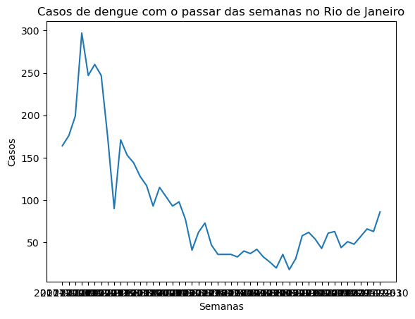

```python
data = dados['data_iniSE']
casos = dados['casos']

fig, ax = plt.subplots()
ax.plot(data, casos)
ax.set_ylabel('Casos')
ax.set_xlabel('Semanas')
ax.set_title('Casos de dengue com o passar das semanas no Rio de Janeiro')
```

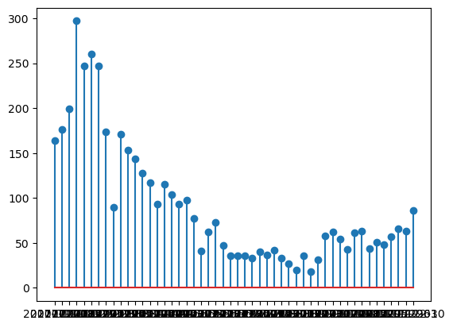

```python
data = dados['data_iniSE']
casos = dados['casos']

plt.stem(data, casos)
plt.show()
```

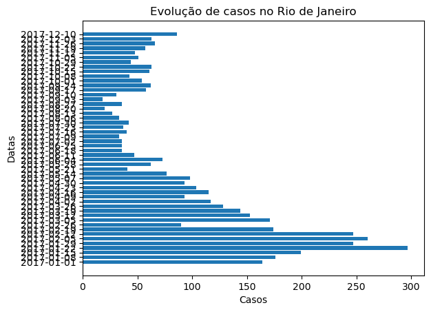

```python
data = dados['data_iniSE']
casos = dados['casos']

plt.rcdefaults()
fig, ax = plt.subplots()
ax.barh(data, casos, align='center')
ax.set_ylabel('Datas')
ax.set_xlabel('Casos')
ax.set_title('Evolução de casos no Rio de Janeiro')
plt.show()
```